# thompson_sampling slides

## Multi-armed bandits with Thompson sampling

Fabio Schmidt-Fischbach

### Presentation on one slide: how to run experiments with many variants.

Classical AB testing suffers from two problems.

- Sample size : enormous sample requirements as # of variants grows.
- Inefficiency : keep pushing users into variants that clearly underperform.

What is Thompson-sampling and how does it help us with testing?

- Core idea: Don't waste samples on variants that are obviously underperforming.  
  --> We are constantly updating our posteriors and allocate traffic according to them.  
  --> "multi-armed bandit testing".

### Which movie to recommend to our users?

[figure not shown]

### ...or in which gambling machine to throw your money in?

[figure not shown]

### Problem description

Setup:

- N variants (e.g. slot machines, movies to recommend, landing pages...)
- each variant $i \in N$ has a reward $x_{i}$ which is unknown to us (e.g. different comms are more or less effective, some movies more or less popular and some slot machines return more or less money).

Goal:

- find the variant $i$ with the highest reward $x_{i}$ by experimentation: $ arg max_{i\in N} x_{i} $

### Solution of classical AB testing

- split traffic equally/or at least at constant splits across your N objects
- run the test either until sample size is reached (frequentist) or until you are confident enough in your results (Bayesian).

### Simulation

- Outcome: conversion - binomial data.
- N = 6 (variants)
- Rewards: $x_{0} = 0.20, x_{1} = 0.33, x_{2} = 0.35, x_{3} = 0.38, x_{4} = 0.34, x_{5} = 0.32$.
- Testing approach: Bayesian (using beta priors for binomial data).

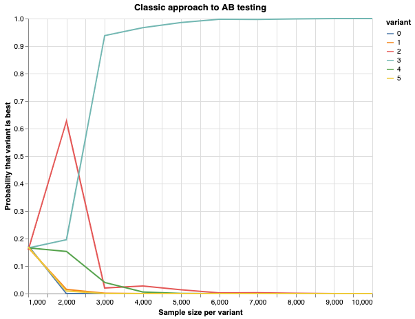

```python
alt.Chart(df).mark_line().encode(
    x=alt.X('N:Q', axis=alt.Axis(title='Sample size per variant')),
    y=alt.Y('value:Q', axis=alt.Axis(title='Probability that variant is best')),
    color='variant:N'
).properties(width=500, height=400, title='Classic approach to AB testing')
```

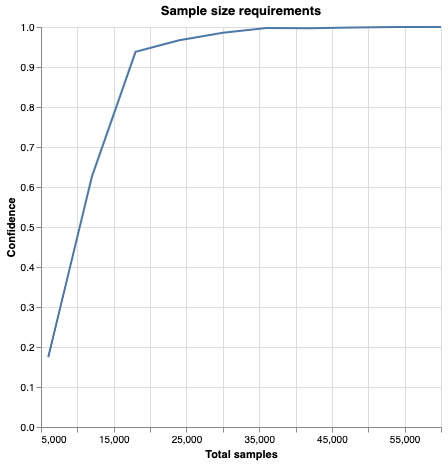

```python
alt.Chart(df).mark_line().encode(
    x=alt.X('N:Q', axis=alt.Axis(title='Total samples')),
    y=alt.Y('value:Q', axis=alt.Axis(title='Confidence'))
).properties(width=400, height=400, title='Sample size requirements')
```

So, sample size is one topic. The other one is "regret"...

For each sample $j$ sent to variant $i$ define the regret as

$ E(regret_{i,j}) = ( x_{i} - arg max_{s \in N} x_{s} ) $

Example? The regret of sending a sample to variant 0 with $x_{0} = 0.20$ is $0.38-0.20=0.18$.

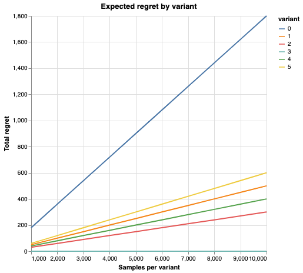

```python
alt.Chart(df).mark_line().encode(
    x=alt.X('N:Q', axis=alt.Axis(title='Samples per variant')),
    y=alt.Y('total_regret:Q', axis=alt.Axis(title='Total regret')),
    color='variant:N'
).properties(width=400, height=400, title='Expected regret by variant')
```

### Multi-armed bandits : an alternative approach to multi-variant testing.

Main idea: avoid sending samples to clearly underperforming variants.

In the jargon of the field, let's move towards exploitation rather than pure exploration.

--> One example algorithm. Thompson sampling.

### Thompson sampling : algorithm

1. Before each observation decide what variant this user will see
   - Thompson sampling: sample one value from each variant-posterior. The next user will see the variant with the highest draw in this round.
2. Wait for the reward to realize
3. Update the posterior of the chosen variant according to the realization in step (2).
4. Evaluate how confident you are in your results (can we stop yet?) and if not continue at (1).

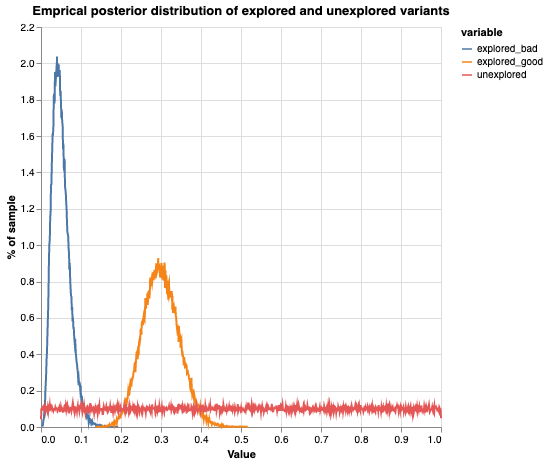

```python
alt.Chart(df).mark_line().encode(
    x=alt.X('value:Q', axis=alt.Axis(title='Value')),
    y=alt.Y('perc:Q', axis=alt.Axis(title='% of sample')),
    color='variable:N'
).properties(width=400, height=400, title='Emprical posterior distribution of explored and unexplored variants')
```

```python
from scipy.stats import bernoulli

# vector with true rewards
x = [0.20, 0.33, 0.35, 0.38, 0.34, 0.32]

# initiate posteriors
start = [1,1]
posteriors = [ start for i in range(len(x))]

# max sample size
max_sample = 100000

# store records of experiment in dictionary.
results = {}

for user in range(max_sample):

    next_variant = decide_next_variant(posteriors)
    # see whether it's a success or not: a single draw from the respective bernuolli.
    success = bernoulli.rvs(x[next_variant], size=1) == 1
    # update posterior
    posteriors = update_posterior(next_variant, posteriors, success)

    if evaluate_confidence(posteriors, 10000) >= 0.95:
        break

    # store every 100th step in results
    if user % 100 == 0:
        results[user] = posteriors.copy()
```

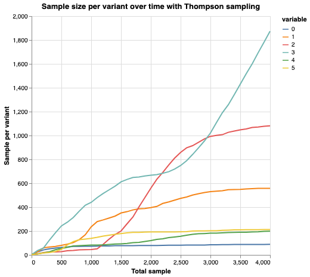

```python
alt.Chart(df).mark_line().encode(
    x=alt.X('index:Q', axis=alt.Axis(title='Total sample')),
    y=alt.Y('value:Q', axis=alt.Axis(title='Sample per variant')),
    color='variable:N'
).properties(width=400, height=400, title='Sample size per variant over time with Thompson sampling')
```

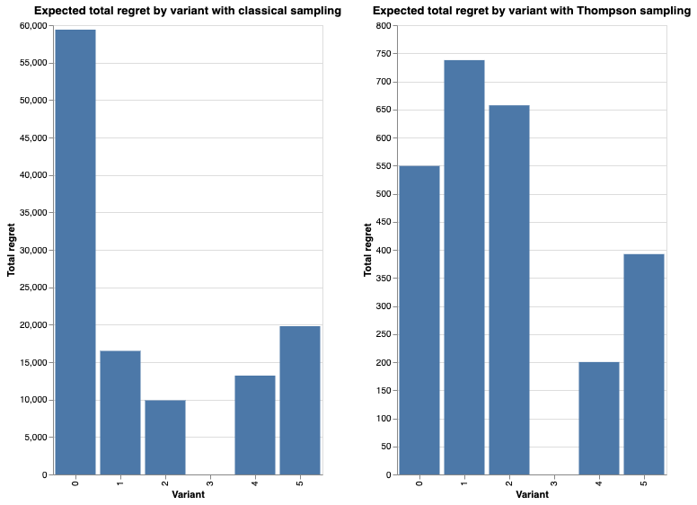

```python
regret_classic | regret_thompson
```

### Summary

- Thompson sampling can be both faster and reduce the losses you make by pushing less traffic to "obviously bad variants".
- Thompson sampling most likely will have more false positives. At least, other's simulation suggest this.

When to use it?

- If you have a large set of variants to test this is most likely the way to go.
- Recommendation systems that condition the variant on a vector X of (user/time characteristics) you use bandits as well (contextual bandits).